# VAE2

Carlos Maia, Pablo Aimar e Vitor Alcântara

2026-06-23

## Parte 1: Análise de Matéria Jornalística

1. Link, Título, Data e Veículo da publicação: -Link: [https://www.intercept.com.br/2025/11/25/grande-midia-clima-negacionismo/] -Título: A grande mídia é cúmplice da desinformação sobre o clima. -Data: 25 de novembro de 2025. -Veículo: Intercept Brasil.
2. Principal mensagem e tópicos abordados: A reportagem aborda como a atuação da grande imprensa corporativa favorece o discurso das empresas de combustíveis fósseis e legitima o negacionismo climático. A mensagem principal do texto gira em torno do conceito de “lacuna de percepção”: embora os dados mostrem que uma esmagadora maioria da população mundial (cerca de 80 a 89%) exija medidas climáticas mais fortes por parte dos governos, a falha e a manipulação na cobertura midiática fazem as pessoas acreditarem, de forma enganosa, que esse apoio é de apenas 30%. O texto também denuncia a proliferação de “publieditoriais” (anúncios pagos disfarçados de conteúdo jornalístico) usados pelas petroleiras para confundir o leitor e maquiar a realidade ambiental.
3. Fonte dos dados: Os argumentos são baseados em pesquisas de opinião, enquetes e estudos revisados por pares realizados por organizações e periódicos reconhecidos, como a Universidade de Yale, Gallup, Nature, Universidade de Oxford e a Comissão Europeia.
4. Opinião sobre a matéria: A matéria condiz de forma precisa com a nossa realidade. Historicamente, empresas de derivados de petróleo são as principais causadoras do aquecimento global, porém investem milhões para manipular narrativas, passando uma falsa sensação de segurança ao público de que estão liderando a transição energética. Sob a ótica da disciplina de Estatísticas Públicas, a reportagem ilustra perfeitamente as vulnerabilidades do atual Ecossistema de Dados, onde atores privados e com fins lucrativos se aproveitam da mídia para gerar Poluição da Informação. Quando essas empresas financiam publieditoriais que misturam dados científicos com publicidade enganosa, elas estão praticando a “malinformation” (informação que pode até conter bases reais, mas é manipulada para causar danos ou distorcer os fatos). Esse tipo de manobra dificulta a mobilização climática e consolida a era da Pós-verdade, fazendo com que o forte apelo de campanhas de marketing se sobreponha à urgência dos fatos e evidências reais sobre o clima.

## Parte 2: A Jornada de Agapito no Ecossistema de Dados Ambientais

- Apresentação: Agapito de Antunes, 33 anos, é um pesquisador focado em áreas ambientais e diretor de produto de uma emergente startup focada na preservação oceânica, inspirada nos modelos da “Infinito Mare”. Como cientista engajado na recuperação de biomas, ele é um usuário crítico e assíduo de estatísticas públicas, acessando frequentemente bases de dados oficiais para entender a dinâmica espacial da degradação ambiental e planejar as inovações tecnológicas de sua empresa.
- Desenvolvimento: Durante a fase de planejamento de um novo sistema para rastreamento de resíduos no litoral, Agapito precisava levantar informações confiáveis sobre as principais fontes de poluentes marinhos e o real nível de engajamento das grandes corporações na transição ecológica. Contudo, ao realizar buscas na internet por dados consolidados que embasassem sua pesquisa, ele se deparou com um cenário informacional confuso e, no meio dessa busca, encontrou a reportagem da Intercept Brasil: “A grande mídia é cúmplice da desinformação sobre o clima”.
- Clímax: A leitura da reportagem provocou um choque de realidade em Agapito, levando-o a um estado de completa desconfiança. Ele descobriu que as grandes empresas petrolíferas frequentemente as maiores responsáveis pelas emissões de poluentes gastam milhões em “publieditoriais”, que são propagandas caras mascaradas com o formato e a linguagem de reportagens jornalísticas legítimas. O pesquisador percebeu que as grandes mídias inflam seus cadernos de sustentabilidade com essas narrativas falsas, criando a chamada “lacuna de percepção”. De repente, Agapito questionou toda a base de informações veiculadas pela imprensa sobre ações corporativas sustentáveis, sentindo-se encurralado em um ambiente onde o poder financeiro das empresas de combustíveis fósseis se sobrepunha aos fatos científicos.
- Desfecho: Em vez de sucumbir ao cinismo ou ao imobilismo gerado pela desinformação, a indignação serviu de catalisador para uma profunda mudança de atitude. Agapito compreendeu que precisava buscar evidências sólidas diretamente nas fontes primárias e oficiais, contornando o ruído midiático. Movido por esse aprendizado, ele mergulhou de forma ainda mais incisiva em seu papel na startup. Seu objetivo tornou-se claro: usar as tecnologias próprias desenvolvidas em sua empresa para identificar fisicamente os poluentes, despoluir os mares e gerar dados primários confiáveis que comprovem o aumento da biodiversidade, combatendo a poluição real com métricas reais, independentes do marketing das petroleiras. Moral da História: A trajetória de Agapito ilustra perfeitamente as armadilhas do atual ecossistema de dados, que se encontra altamente vulnerável à poluição da informação (malinformation) por parte de atores com interesses comerciais. Sob a perspectiva do usuário, a história ensina que a cadeia de valor do dado só atinge seu pleno potencial quando a informação é criticamente filtrada e transformada em uma ação prática benéfica à sociedade no caso, a inovação tecnológica para despoluição. Fica evidente, portanto, a urgência de se promover o letramento de dados não apenas para capacitar os cidadãos a distinguirem fatos de propagandas (greenwashing), mas sobretudo para os profissionais de mídia, que deveriam atuar como guardiões da integridade informacional, impedindo que os interesses corporativos perpetuem a pós-verdade na pauta climática.

## Parte 3: O Uso de Dados Oficiais para a Tomada de Decisão

Para que Agapito consiga direcionar os esforços de sua startup com base em evidências reais, contornando a poluição de informação das campanhas de greenwashing das grandes empresas, ele recorreu ao SIDRA/IBGE. Utilizando os descritores adequados no painel de busca, ele extraiu dados da Pesquisa Nacional de Saneamento Básico (PNSB), focando especificamente nas Tabelas 1241 e 2064.

**Pesquisa Nacional de Saneamento Básico (PNSB)** e disponíveis no SIDRA:

- **Tabela 1241 (Municípios com manejo de resíduos sólidos e situação da coleta seletiva):** Esta tabela permitiu a Agapito mapear a infraestrutura de limpeza urbana. Ao identificar os municípios litorâneos que ainda possuem déficits na coleta seletiva de resíduos, ele pôde prever os principais pontos de vulnerabilidade onde o lixo sólido urbano (como plásticos) tem maior probabilidade de escapar para o oceano, direcionando as tecnologias de contenção física de sua empresa para essas áreas.
- **Tabela 2064 (Quantidade coletada de resíduos sólidos industriais perigosos e/ou não-inertes):** Ao analisar esta base, Agapito constatou que a geração de resíduos perigosos não é homogênea, estando fortemente concentrada nas matrizes industriais do Sul (com indicador de 2.089,3) e do Sudeste (1.210,7). O estado de São Paulo, principal polo petroquímico e industrial, apresentou 1.171,4 em volume coletado.

```r
library(here)
library(readxl)
library(dplyr)
```

```r
library(stringr)
library(tidyr)
library(ggplot2)
library(knitr)
```

```r
# Aba 1 da tabela 2064: número de municípios que coletam resíduos perigosos (2008)
contagem_2064 <- read_excel(
  here("tabela2064.xlsx"),
  sheet = 1,
  skip = 4,
  col_names = c("local", "n_coletam_2008"),
  col_types = c("text", "numeric")
)

# Aba 2 da tabela 2064: quantidade coletada, em toneladas/dia (2008)
# "-" siginifica zero absoluto (ver aba "Notas" da planilha original)
quantidade_2064 <- read_excel(
  here("tabela2064.xlsx"),
  sheet = 2,
  skip = 4,
  col_names = c("local", "qtd_raw"),
  col_types = c("text", "text")
) %>%
  mutate(
    qtd_coletada_ton_dia = if_else(str_trim(qtd_raw) == "-", 0,
                                    suppressWarnings(as.numeric(qtd_raw)))
  ) %>%
  select(local, qtd_coletada_ton_dia)
```

```r
# Tabela 1241, aba "Tabela 1": total geral de municípios em 2000 e 2008
# ".." significa "não disponível" naquele nível/ano (ver legenda da planilha original)
total_municipios <- read_excel(
  here("tabela1241.xlsx"),
  sheet = "Tabela 1",
  skip = 5,
  col_names = c("local", "total_2000_raw", "total_2008_raw"),
  col_types = c("text", "text", "text")
) %>%
  mutate(
    total_municipios_2000 = suppressWarnings(as.numeric(total_2000_raw)),
    total_municipios_2008 = suppressWarnings(as.numeric(total_2008_raw))
  ) %>%
  select(local, total_municipios_2000, total_municipios_2008)
```

```r
regioes <- c("Norte", "Nordeste", "Sudeste", "Sul", "Centro-Oeste")

ufs <- c("Rondônia", "Acre", "Amazonas", "Roraima", "Pará", "Amapá", "Tocantins",
         "Maranhão", "Piauí", "Ceará", "Rio Grande do Norte", "Paraíba", "Pernambuco",
         "Alagoas", "Sergipe", "Bahia", "Minas Gerais", "Espírito Santo", "Rio de Janeiro",
         "São Paulo", "Paraná", "Santa Catarina", "Rio Grande do Sul", "Mato Grosso do Sul",
         "Mato Grosso", "Goiás", "Distrito Federal")

classificar_nivel <- function(local) {
  case_when(
    local == "Brasil"                       ~ "Brasil",
    local %in% regioes                      ~ "Região",
    local %in% ufs                          ~ "UF",
    str_starts(local, "Grupo")              ~ "Grupo populacional",
    str_detect(local, "\\([A-Z]{2}\\)$")    ~ "Município/RM",
    TRUE                                     ~ "Outro"
  )
}
```

```r
base_2064 <- contagem_2064 %>%
  left_join(quantidade_2064, by = "local") %>%
  mutate(nivel = classificar_nivel(local)) %>%
  filter(nivel %in% c("Brasil", "Região", "UF"))
base_1241 <- total_municipios %>%
  mutate(nivel = classificar_nivel(local)) %>%
  filter(nivel %in% c("Brasil", "Região", "UF"))
```

```r
painel <- base_1241 %>%
  left_join(
    base_2064 %>% select(local, n_coletam_2008, qtd_coletada_ton_dia),
    by = "local"
  ) %>%
  mutate(
    n_coletam_2008       = replace_na(n_coletam_2008, 0),
    qtd_coletada_ton_dia = replace_na(qtd_coletada_ton_dia, 0),
    cobertura_pct = 100 * n_coletam_2008 / total_municipios_2008,
    qtd_media_ton_dia_por_municipio = if_else(
      n_coletam_2008 > 0,
      qtd_coletada_ton_dia / n_coletam_2008,
      NA_real_
    )
  )

painel_brasil <- filter(painel, nivel == "Brasil")
painel_regiao <- filter(painel, nivel == "Região") %>% arrange(desc(cobertura_pct))
painel_uf     <- filter(painel, nivel == "UF")     %>% arrange(desc(cobertura_pct))
```

```r
painel_brasil %>%
  select(local, total_municipios_2008, n_coletam_2008, cobertura_pct, qtd_coletada_ton_dia) %>%
  kable(
    col.names = c("Brasil", "Total de municípios (2008)", "Municípios que coletam",
                  "Cobertura (%)", "Quantidade coletada (t/dia)"),
    digits = 2
  )
```

| Brasil | Total de municípios (2008) | Municípios que coletam | Cobertura (%) | Quantidade coletada (t/dia) |
| --- | --- | --- | --- | --- |
| Brasil | 5564 | 136 | 2.44 | 3444 |

```r
painel_regiao %>%
  select(local, total_municipios_2008, n_coletam_2008, cobertura_pct,
         qtd_coletada_ton_dia, qtd_media_ton_dia_por_municipio) %>%
  kable(
    col.names = c("Região", "Total de municípios", "Municípios que coletam",
                  "Cobertura (%)", "Qtd. coletada (t/dia)", "Qtd. média/município (t/dia)"),
    digits = 2
  )
```

| Região | Total de municípios | Municípios que coletam | Cobertura (%) | Qtd. coletada (t/dia) | Qtd. média/município (t/dia) |
| --- | --- | --- | --- | --- | --- |
| Sul | 1188 | 45 | 3.79 | 2089.3 | 46.43 |
| Sudeste | 1668 | 39 | 2.34 | 1210.7 | 31.04 |
| Norte | 449 | 10 | 2.23 | 9.5 | 0.95 |
| Nordeste | 1793 | 35 | 1.95 | 81.4 | 2.33 |
| Centro-Oeste | 466 | 7 | 1.50 | 53.1 | 7.59 |

```r
painel_uf %>%
  select(local, total_municipios_2008, n_coletam_2008, cobertura_pct,
         qtd_coletada_ton_dia, qtd_media_ton_dia_por_municipio) %>%
  kable(
    col.names = c("UF", "Total de municípios", "Municípios que coletam",
                  "Cobertura (%)", "Qtd. coletada (t/dia)", "Qtd. média/município (t/dia)"),
    digits = 2
  )
```

| UF | Total de municípios | Municípios que coletam | Cobertura (%) | Qtd. coletada (t/dia) | Qtd. média/município (t/dia) |
| --- | --- | --- | --- | --- | --- |
| Paraná | 399 | 25 | 6.27 | 2015.9 | 80.64 |
| Santa Catarina | 293 | 15 | 5.12 | 61.2 | 4.08 |
| Ceará | 184 | 9 | 4.89 | 18.1 | 2.01 |
| Pará | 143 | 6 | 4.20 | 8.1 | 1.35 |
| Sergipe | 75 | 3 | 4.00 | 4.5 | 1.50 |
| Alagoas | 102 | 4 | 3.92 | 1.6 | 0.40 |
| Espírito Santo | 78 | 3 | 3.85 | 20.8 | 6.93 |
| Rio de Janeiro | 92 | 3 | 3.26 | 2.3 | 0.77 |
| Tocantins | 139 | 4 | 2.88 | 1.4 | 0.35 |
| Minas Gerais | 853 | 24 | 2.81 | 16.2 | 0.67 |
| Bahia | 417 | 9 | 2.16 | 48.2 | 5.36 |
| Goiás | 246 | 5 | 2.03 | 2.6 | 0.52 |
| Mato Grosso | 141 | 2 | 1.42 | 50.5 | 25.25 |
| São Paulo | 645 | 9 | 1.40 | 1171.4 | 130.16 |
| Piauí | 223 | 3 | 1.35 | 0.7 | 0.23 |
| Paraíba | 223 | 3 | 1.35 | 0.9 | 0.30 |
| Pernambuco | 185 | 2 | 1.08 | 1.0 | 0.50 |
| Rio Grande do Sul | 496 | 5 | 1.01 | 12.2 | 2.44 |
| Maranhão | 217 | 2 | 0.92 | 6.4 | 3.20 |
| Rondônia | 52 | 0 | 0.00 | 0.0 | NA |
| Acre | 22 | 0 | 0.00 | 0.0 | NA |
| Amazonas | 62 | 0 | 0.00 | 0.0 | NA |
| Roraima | 15 | 0 | 0.00 | 0.0 | NA |
| Amapá | 16 | 0 | 0.00 | 0.0 | NA |
| Rio Grande do Norte | 167 | 0 | 0.00 | 0.0 | NA |
| Mato Grosso do Sul | 78 | 0 | 0.00 | 0.0 | NA |
| Distrito Federal | 1 | 0 | 0.00 | 0.0 | NA |

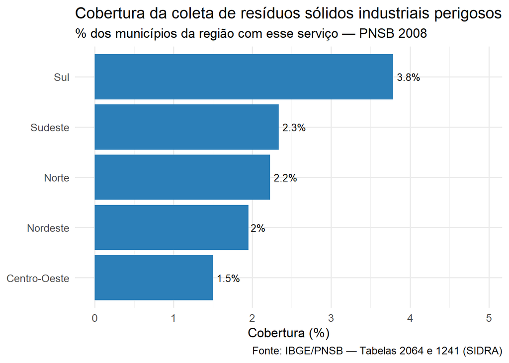

```r
ggplot(painel_regiao, aes(x = reorder(local, cobertura_pct), y = cobertura_pct)) +
  geom_col(fill = "#2c7fb8") +
  geom_text(aes(label = paste0(round(cobertura_pct, 1), "%")), hjust = -0.15, size = 3.6) +
  coord_flip() +
  scale_y_continuous(limits = c(0, max(painel_regiao$cobertura_pct) * 1.3)) +
  labs(
    title = "Cobertura da coleta de resíduos sólidos industriais perigosos",
    subtitle = "% dos municípios da região com esse serviço — PNSB 2008",
    x = NULL, y = "Cobertura (%)",
    caption = "Fonte: IBGE/PNSB — Tabelas 2064 e 1241 (SIDRA)"
  ) +
  theme_minimal(base_size = 13)
```

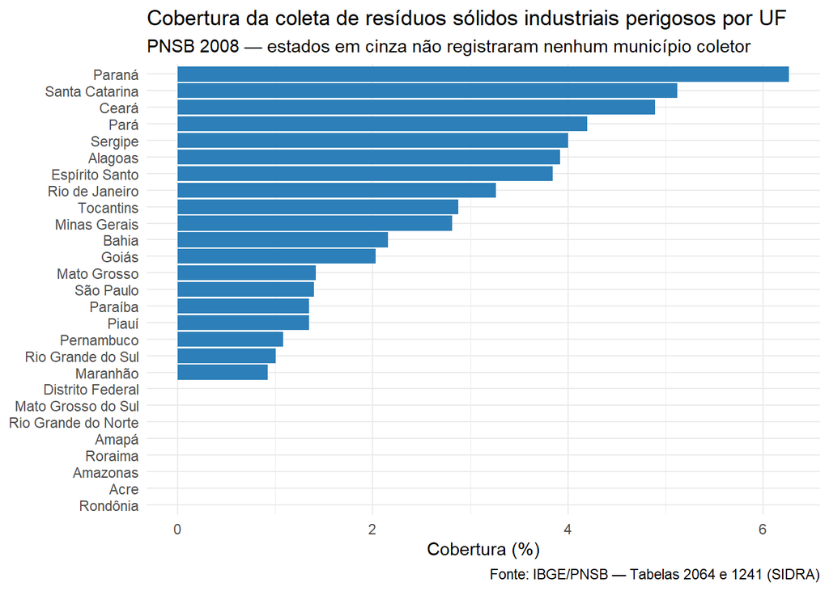

```r
painel_uf %>%
  mutate(local = factor(local, levels = local[order(cobertura_pct)])) %>%
  ggplot(aes(x = local, y = cobertura_pct, fill = cobertura_pct > 0)) +
  geom_col() +
  coord_flip() +
  scale_fill_manual(values = c(`TRUE` = "#2c7fb8", `FALSE` = "grey80"), guide = "none") +
  labs(
    title = "Cobertura da coleta de resíduos sólidos industriais perigosos por UF",
    subtitle = "PNSB 2008 — estados em cinza não registraram nenhum município coletor",
    x = NULL, y = "Cobertura (%)",
    caption = "Fonte: IBGE/PNSB — Tabelas 2064 e 1241 (SIDRA)"
  ) +
  theme_minimal(base_size = 11)
```

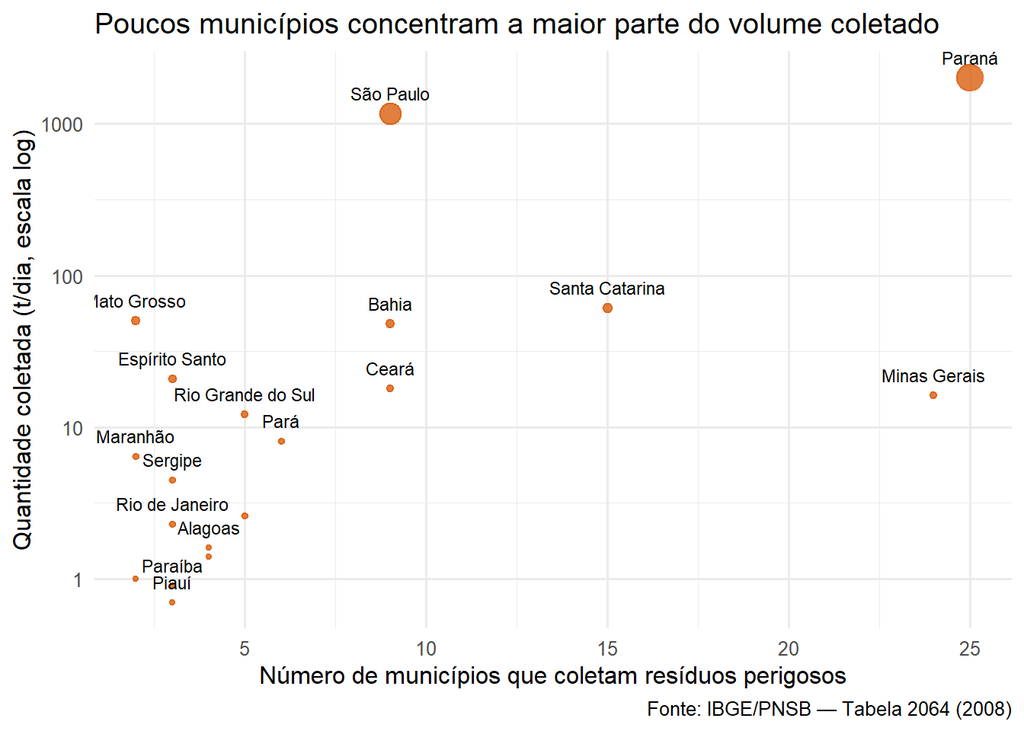

```r
painel_uf %>%
  filter(n_coletam_2008 > 0) %>%
  ggplot(aes(x = n_coletam_2008, y = qtd_coletada_ton_dia)) +
  geom_point(aes(size = qtd_coletada_ton_dia), color = "#d95f0e", alpha = 0.8) +
  geom_text(aes(label = local), size = 3, vjust = -1, check_overlap = TRUE) +
  scale_y_log10() +
  guides(size = "none") +
  labs(
    title = "Poucos municípios concentram a maior parte do volume coletado",
    x = "Número de municípios que coletam resíduos perigosos",
    y = "Quantidade coletada (t/dia, escala log)",
    caption = "Fonte: IBGE/PNSB — Tabela 2064 (2008)"
  ) +
  theme_minimal(base_size = 12)
```

```r
concentracao_sp_pr <- painel_uf %>%
  filter(local %in% c("São Paulo", "Paraná")) %>%
  summarise(soma = sum(qtd_coletada_ton_dia)) %>%
  pull(soma)

pct_concentracao_sp_pr <- 100 * concentracao_sp_pr / painel_brasil$qtd_coletada_ton_dia

n_uf_zero <- sum(painel_uf$n_coletam_2008 == 0)
```

## O que os números mostram (e a mídia não costuma mostrar)

Em 2008, apenas 136 dos 5564 municípios brasileiros (**2.4%**) tinham algum serviço de coleta de resíduos sólidos industriais perigosos e/ou não-inertes. Em outras palavras, para mais de 97% dos municípios do país esse tipo de resíduo simplesmente não tinha, segundo o próprio IBGE, um destino formalmente monitorado.

A distribuição é, além de baixa, extremamente desigual: 8 Unidades da Federação não registraram nenhum município com esse serviço, enquanto São Paulo e Paraná, somados, concentram **92.5%** de toda a quantidade coletada no país — mesmo cobrindo uma fração pequena dos seus próprios municípios (1,4% em São Paulo e 6,3% no Paraná). Ou seja: a gestão formal de resíduos perigosos no Brasil não está distribuída de acordo com a necessidade ambiental do território, e sim concentrada em poucos polos industriais.

Esse tipo de assimetria é exatamente o que a “lacuna de percepção” discutida na Parte 1 tende a esconder: discursos corporativos de sustentabilidade — e os publieditoriais que os veiculam — falam em termos vagos de “transição” e “responsabilidade ambiental”, mas raramente mencionam que a infraestrutura formal de tratamento de resíduos perigosos cobre uma fatia mínima e geograficamente concentrada do país. É só descendo ao dado primário do IBGE — exatamente o movimento que Agapito faz na Parte 2, ao abandonar as fontes midiáticas e buscar evidência oficial — que essa desigualdade aparece com números concretos.

## Considerações finais

A análise confirma, com dados oficiais, o argumento central das Partes 1 e 2: informação ambiental de qualidade não nasce de publieditoriais nem de notícias soltas, mas de séries estatísticas públicas, sistematizadas e auditáveis, como a PNSB do IBGE. O exercício de cruzar a Tabela 2064 com a Tabela 1241 — duas tabelas que, isoladamente, dizem pouco — ilustra também a importância do **letramento de dados** defendido na “Moral da História” da Parte 2: saber onde buscar a fonte primária e como tratá-la (lidar com a hierarquia geográfica, os códigos de valor ausente/zero etc.) é o que transforma um dado bruto em evidência útil para entender — e cobrar — políticas públicas de saneamento e resíduos industriais.

## Referências

- Intercpt Brasil. **A grande mídia é cúmplice da desinformação sobre o clima**
- IBGE. **Pesquisa Nacional de Saneamento Básico (PNSB) — 2008.** Sistema IBGE de Recuperação Automática (SIDRA), Tabela 2064 — Número de municípios que coletam resíduos sólidos industriais perigosos e/ou não-inertes e quantidade coletada.
- IBGE. **Pesquisa Nacional de Saneamento Básico (PNSB).** Sistema IBGE de Recuperação Automática (SIDRA), Tabela 1241 — Número de municípios, total e os com manejo de resíduos sólidos, por situação da coleta seletiva no município. Disponível em: sidra.ibge.gov.br/tabela/1241.

## Declaração de Uso de IA

Declaramos que utilizamos ferramentas de Inteligência Artificial apenas para auxiliar na estruturação do texto, na revisão gramatical e na correção das linhas de código, conforme autorizado na disciplina. O conteúdo, as ideias e a organização dos assuntos foram elaborados por nós, com base nos slides da professora.